# Statistical inference with the GSS data

## Setup

### Load packages and set local time

```r
library(ggplot2)
library(dplyr)
library(tibble)
library(forcats)
library(statsr)
Sys.setlocale("LC_TIME", "C")
```

```
## [1] "C"
```

### Load data

```r
load("gss.Rdata")
```

## Part 1: Data

Each survey from 1972 to 2004 was an independently drawn sample of English-speaking persons 18 years of age or over, living in non-institutional arrangements within the United States. Starting in 2006 Spanish-speakers were added to the target population. Block quota sampling was used in 1972, 1973, and 1974 surveys and for half of the 1975 and 1976 surveys. Full probability sampling was employed in half of the 1975 and 1976 surveys and the 1977, 1978, 1980, 1982-1991, 1993-1998, 2000, 2002, 2004, 2006, 2008, 2010, 2012, 2014, and 2016 surveys. Also, the 2004, 2006, 2008, 2010, 2012, 2014, and 2016 surveys had sub-sampled non-respondents.  
Difference between block quota sampling and full probability sampling methods may affect comperison beteen data from 1972-1976 and later years.

Independently drawn sample means **random sampling method**, so inference from this data **can be generalized**.  
Nevertheless, institutionalized persons and non-English speaking persons (except Spanish-speakers since 2006) did not participated in this surveys, which way cause convenience sample bias.  
Data was collected in a way that does not directly interfere with how the data arise, so there was no random assignment, and **causal connections cannot be established**.

## Part 2: Research question

Are there difference in attitude to homosexual relations in 1977 and 2012?

It’s interesting to see, if/how attitude on one of the human rights changed in 35 years.  
I’ve used 1977 year because it’s first year with full probability sampling method used, and 2012 as a year with latest data available.

## Part 3: Exploratory data analysis

First let’s create subset the data of interest. To answer the question, I will use variables “year” and “homosex”.

```r
attitude <- c("Always Wrong", "Almst Always Wrg", "Sometimes Wrong", "Not Wrong At All")
dataset <- as_tibble(gss) %>%
    filter(year==1977 | year==2012) %>%
    filter(!is.na(year)&!is.na(homosex)) %>%
    mutate(homosex = factor(as.character(homosex), levels = attitude), year = as.factor(year)) %>%
    select(year, homosex)
print(dataset, n=3)
```

```
## # A tibble: 2,692 x 2
##   year  homosex
##   <fct> <fct>
## 1 1977  Always Wrong
## 2 1977  Always Wrong
## 3 1977  Always Wrong
## # ... with 2,689 more rows
```

In the survey the question was formulated as:  
“What about sexual relations between two adults of the same sex?”  
Let’s look how our variables distribute:

```r
group_by(dataset, year) %>% summarise(n())
```

```
## # A tibble: 2 x 2
##   year  `n()`
##   <fct> <int>
## 1 1977   1453
## 2 2012   1239
```

```r
table(dataset)
```

```
##       homosex
## year   Always Wrong Almst Always Wrg Sometimes Wrong Not Wrong At All
##   1977         1044               84             109              216
##   2012          567               37              82              553
```

In our samples both in 1977 and 2012 the most popular opinion about homosexual relations is “Always Wrong”, but the distribution of opinions is very vary in 2012.

To visualize opinion distribution let’s make side-by-side bar plot:

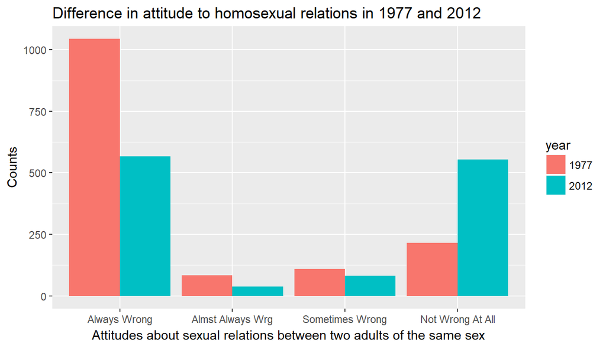

```r
g <- ggplot(data = dataset) +
    geom_bar(mapping = aes(x = homosex, fill = year), position = "dodge") +
    labs(x="Attitudes about sexual relations between two adults of the same sex", y="Counts", title="Difference in attitude to homosexual relations in 1977 and 2012")
print(g)
```

## Part 4: Inference

For statistical inference first let’s formulate **hypotheses test**:  
*H0 (nothing going on):* Attitude to homosexual relations and survey years are **independent**. Attitude dictribution **does not vary** by the survey years.  
*HA (something going on):* Attitude to homosexual relations and survey years are **dependent**. Attitude dictribution **does vary** by the survey years.

Conditions check list:  
1. **Independence**  
* independently drawn sample (by the data description)  
* sampling without replacement -> <10% of population (survey contain < then 10% of all adult population of USA)  
* each case only contributes to one cell in the table (one case - one answer) 2. **Sample size:** each particular cell must have at least 5 expected cases. (let’s check it later)

This are hypotheses with 2 categorical variables, and at least one of them has multiple levels, so I will use the **Chi-Square Independence test** with significance level a = 0.05.  
For Chi-square testing there is no associated confidence interval method or other methods to compare.  
Let’s again look at the table representation of the data:

```r
contingency_table <- table(dataset)
print(contingency_table)
```

```
##       homosex
## year   Always Wrong Almst Always Wrg Sometimes Wrong Not Wrong At All
##   1977         1044               84             109              216
##   2012          567               37              82              553
```

Now let’s look at the expected counts for this table (each of them are evaluated as (row total)*(column total)/(table total))

```r
chisq.test(contingency_table)$expected
```

```
##       homosex
## year   Always Wrong Almst Always Wrg Sometimes Wrong Not Wrong At All
##   1977     869.5331         65.30944       103.09175         415.0658
##   2012     741.4669         55.69056        87.90825         353.9342
```

Each cell has at least 5 expected cases, so all conditios in the check list for theoretical Chi-Square test are met.  
Now we need to calculate the sum of ([O]-[E])^2/[E] values (Chi-Square) and evaluate p-value by Chi-Square statistics with appropriate degrees of freedom.  
In R it’s ease to use build-in “chisq.test” function.

```r
chisq.test(contingency_table)
```

```
##
##  Pearson's Chi-squared test
##
## data:  contingency_table
## X-squared = 295.85, df = 3, p-value < 2.2e-16
```

p-value is very low (2.2e-16), it is much lower then significance level (0.05), so we reject the null hypothesis in favour of alternative hypothesis: Attitude to homosexual relations and years are dependent. Attitude dictribution does vary by the years.  
There is 2.2e-16 chance that observed or more extreme outcome would be obtained if the null hypothesis is true (Attitude to homosexual relations and survey years are independent).

## Summary

Analysis shows, that distributions of answers to the survey question “What about sexual relations between two adults of the same sex?” are sighificantly different in 1977 and 2012 years. Even if attitude was ordered categorical variable with many levels, our research question doesn’t show direction, in which attitude changed.  
In future research it would be interesting to explore the dynamics of attitude to homosexual relations in all available years.